# Bayesian Networks

Verena Brufatto

# Dataset description

This contains data on coronary artery disease from a Danish heart clinic. The dataset contains 14 discrete variables recorded for 236 patients, 107 of whom actually had the disease. The dataset includes five background variables (sex, hypercholesterolemia, smoking, heridary disposition and workload), one recording whether or not the patient has coronary artery disease, four variables representing disease manifestation (hypertrophy, previous myocardial infarct, angina pectoris, other heartfailures), and four clinical measurements (Qwave, T-wave, Q-wave informative and T-wave informative). Angina pectoris has 3 levels and the remaining 13 variables are binary.

```
## cad1
##
##  14  Variables      236  Observations
## --------------------------------------------------------------------------------
## Sex
##        n  missing distinct
##      236        0        2
##
## Value      Female   Male
## Frequency      47    189
## Proportion  0.199  0.801
## --------------------------------------------------------------------------------
## AngPec
##        n  missing distinct
##      236        0        3
##
## Value      Atypical     None  Typical
## Frequency        30       85      121
## Proportion    0.127    0.360    0.513
## --------------------------------------------------------------------------------
## AMI
##        n  missing distinct
##      236        0        2
##
## Value        Definite NotCertain
## Frequency          63        173
## Proportion      0.267      0.733
## --------------------------------------------------------------------------------
## QWave
##        n  missing distinct
##      236        0        2
##
## Value         No   Yes
## Frequency    153    83
## Proportion 0.648 0.352
## --------------------------------------------------------------------------------
## QWavecode
##        n  missing distinct
##      236        0        2
##
```

[output cut: 61 more lines]

```
##        n  missing distinct
##      236        0        2
##
## Value        No  Yes
## Frequency   177   59
## Proportion 0.75 0.25
## --------------------------------------------------------------------------------
## CAD
##        n  missing distinct
##      236        0        2
##
## Value         No   Yes
## Frequency    129   107
## Proportion 0.547 0.453
## --------------------------------------------------------------------------------
```

# Blacklist

A better approach is to incorporate our prior knowledge of the system under study into the model selection process.

The variables are divided into four blocks, namely background variables, disease (which includes CAD and hypertrophy), disease manifestations and clinical measurements. We restrict the model selection process by blacklisting arcs that point from a later to an earlier block. We also blacklist arcs that point from being a smoker to having an hereditary disposition and from smoker, hypercholesterolemia, hereditary and workload to sex. In addition, we assume independence between different clincal tests, so that STchange and STcode cannot influence QWave and QWavecode and viceversa. Finally, we impose that the confidence on a test result (STcode and QWavecode) cannot influence whether or not a test is run (STchange, QWave).

```
##           from          to
## 1       AngPec         Sex
## 2       AngPec  SuffHeartF
## 3       AngPec Hypertrophi
## 4       AngPec   Hyperchol
## 5       AngPec      Smoker
## 6       AngPec     Inherit
## 7       AngPec         CAD
## 8          AMI         Sex
## 9          AMI  SuffHeartF
## 10         AMI Hypertrophi
## 11         AMI   Hyperchol
## 12         AMI      Smoker
## 13         AMI     Inherit
## 14         AMI         CAD
```

[output cut: 72 more lines]

# Learn network structure

## True CPDAG

We assume that the true CPDAG is the one described in Hojsgaard and Thiesson (1993). The true CPDAG has 19 arcs of which 2 undirected.

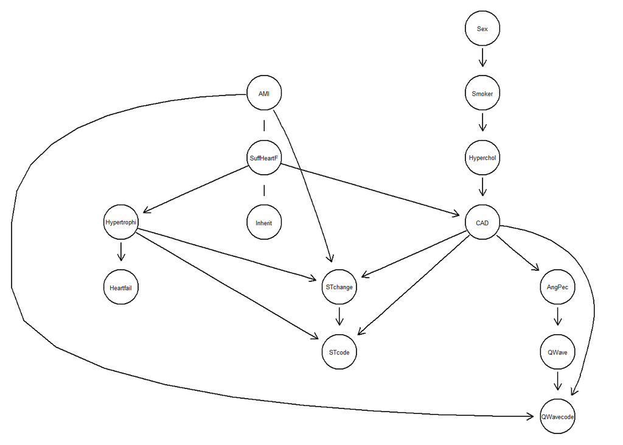

## Score based algorithms

### Hill climbing algorithm

```r
bn_hc <- hc(cad1, blacklist=blackL)
```

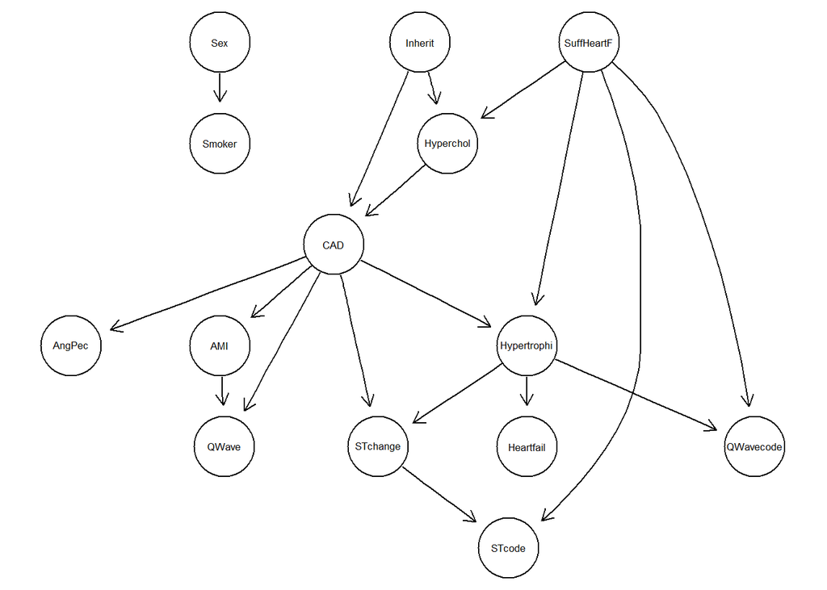

```r
unlist( bnlearn::compare(true_dag, cpdag(bn_hc)) )
```

```
## tp fp fn
##  7 11 12
```

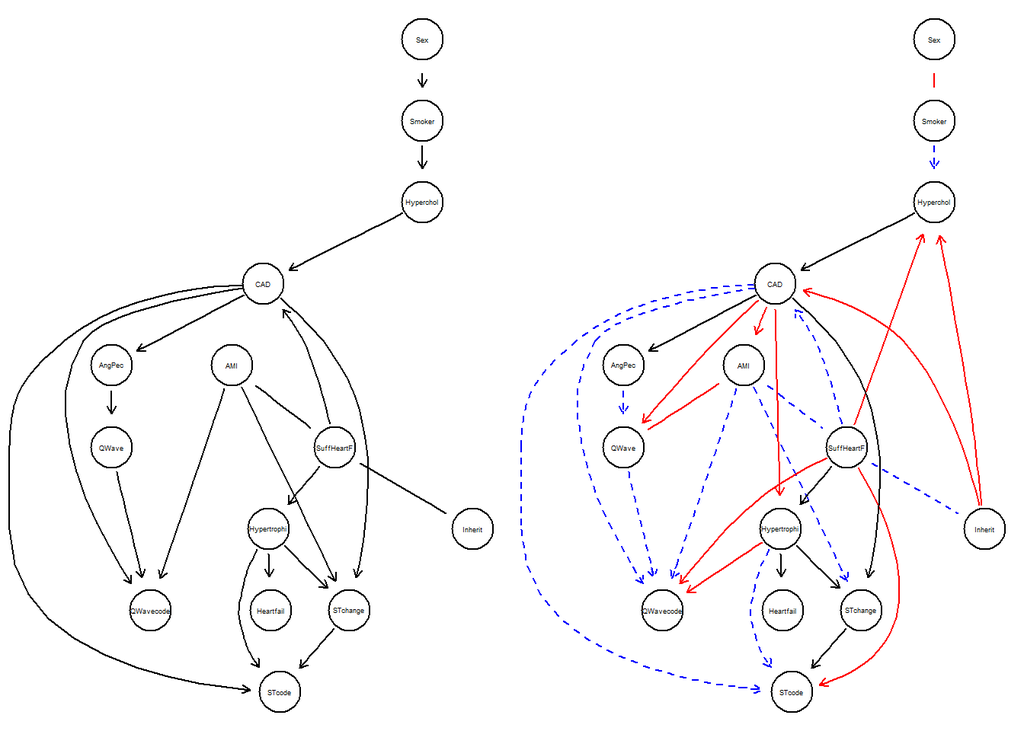

### Hill climbing algorithm with random restarts

```r
hc_restart = hc(cad1, score = "bde", iss = 1, restart = 10, perturb = 5, blacklist=blackL)
```

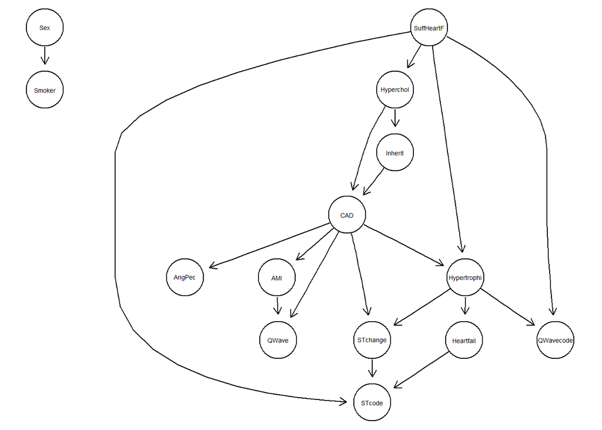

```r
# compare score based algorithms

all.equal(bn_hc, hc_restart)
```

```
## [1] "Different number of directed/undirected arcs"
```

```r
unlist( bnlearn::compare(bn_hc, hc_restart) )
```

```
## tp fp fn
## 17  2  1
```

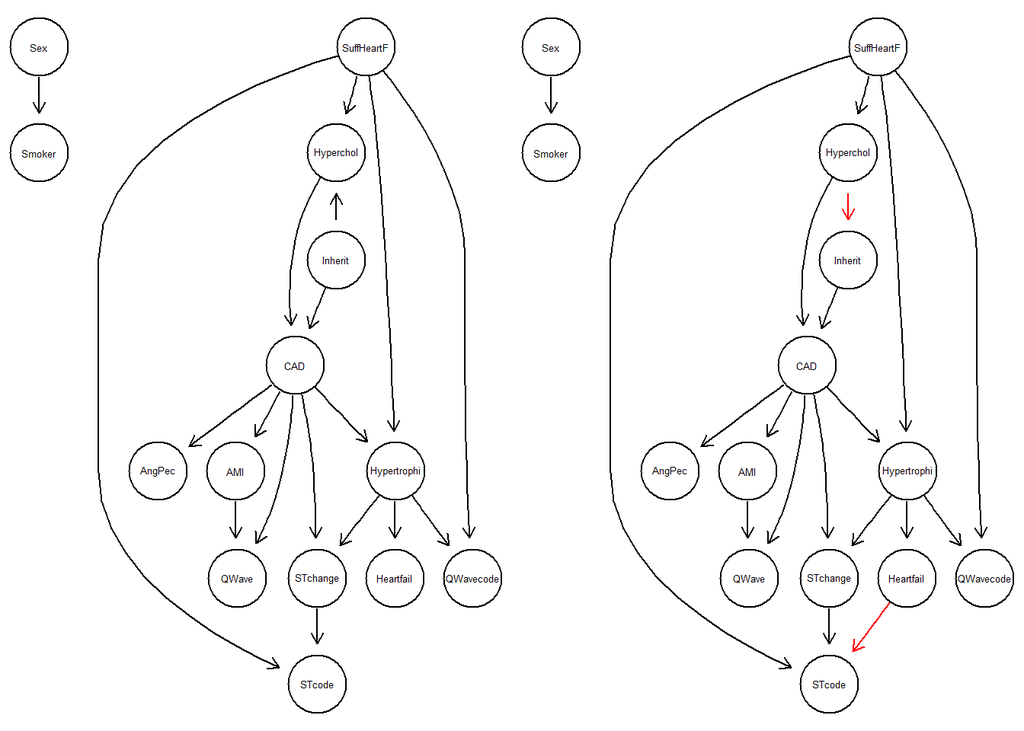

Based on the network score, the DAG produced with the hill climbing algorithm with random restarts provides a slightly worse fit to the data.

```
## [1] -1801.804 -1806.889
```

```r
# compare with true dag
unlist( bnlearn::compare(true_dag, cpdag(hc_restart)) )
```

```
## tp fp fn
##  5 14 14
```

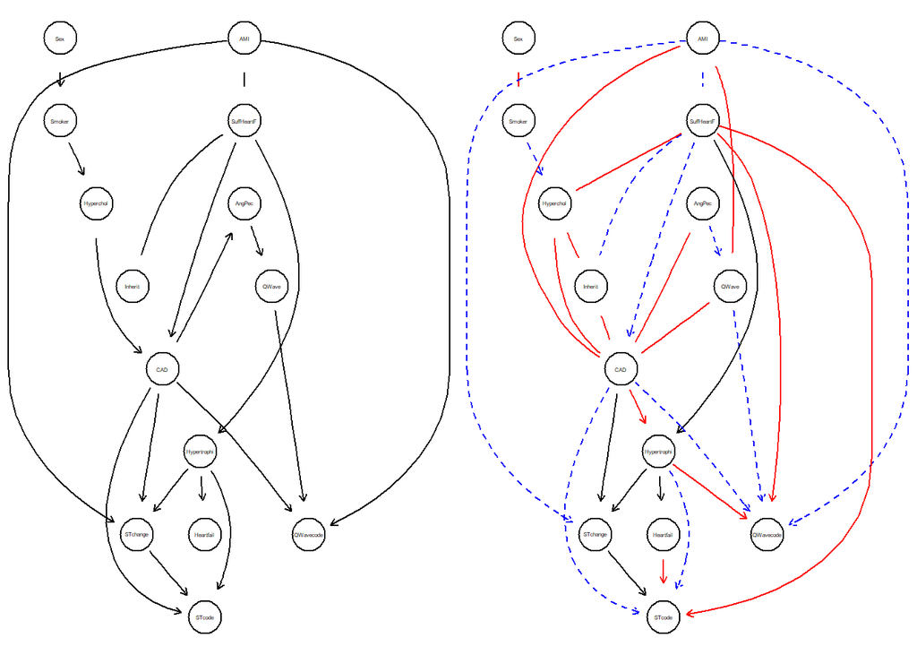

## Constraint based algorithms

### Semi-Interleaved Hiton-PC

```r
bn_hit <- si.hiton.pc(cad1, undirected = F,
                      blacklist = blackL)
```

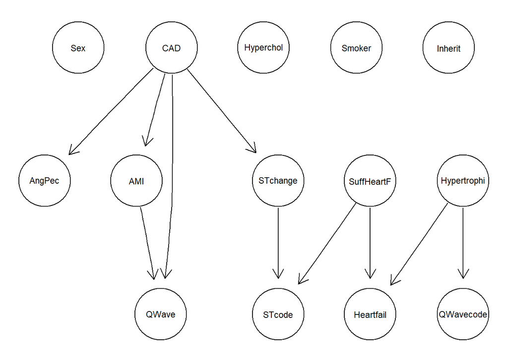

```r
unlist( bnlearn::compare(true_dag, bn_hit) )
```

```
## tp fp fn
##  4  6 15
```

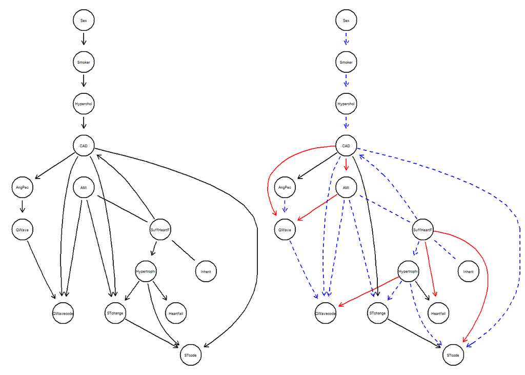

### Hiton-PC with permutation tests

```r
bn_hit2 = si.hiton.pc(cad1, test = "mc-mi", undirected = FALSE,
                      blacklist = blackL)
```

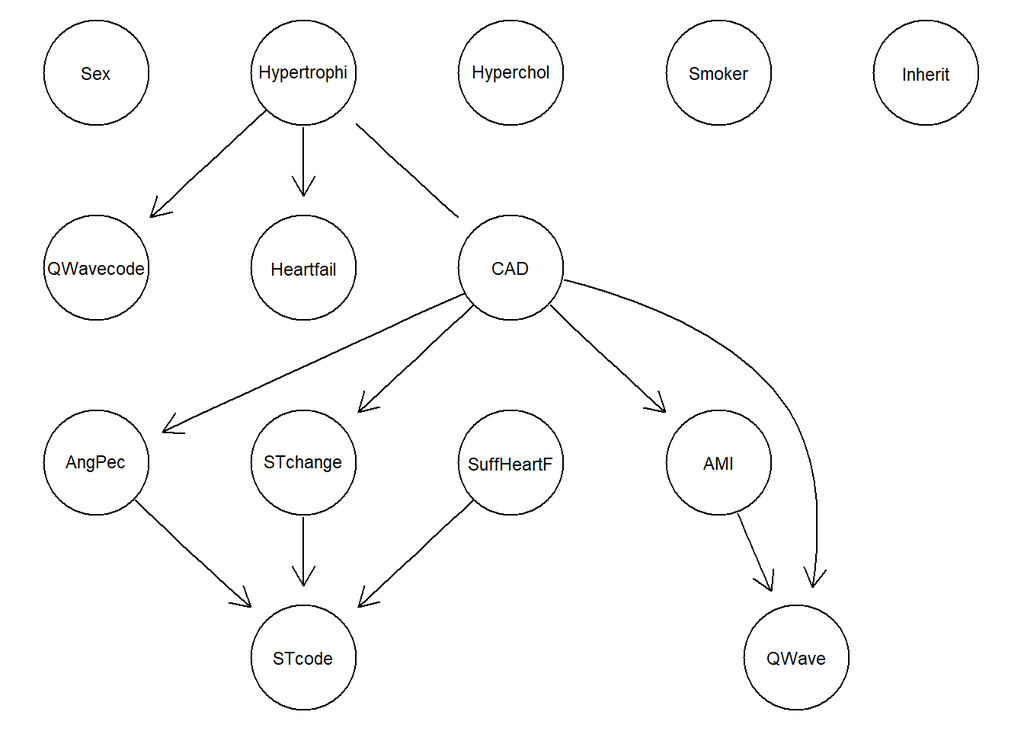

```r
unlist( bnlearn::compare(bn_hit, bn_hit2) )
```

```
## tp fp fn
##  9  2  1
```

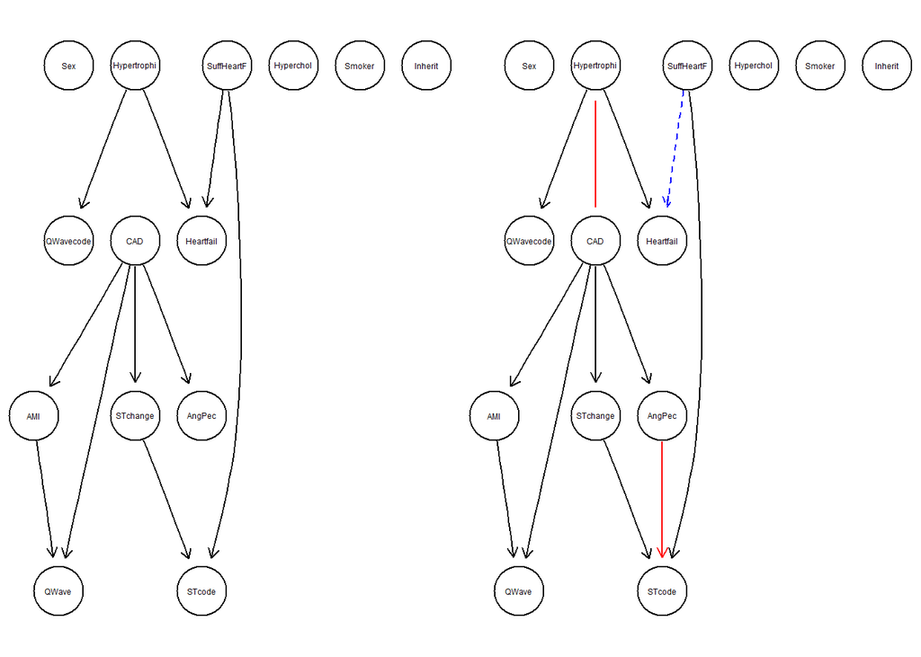

```r
unlist( bnlearn::compare(true_dag, bn_hit2) )
```

```
## tp fp fn
##  4  7 15
```

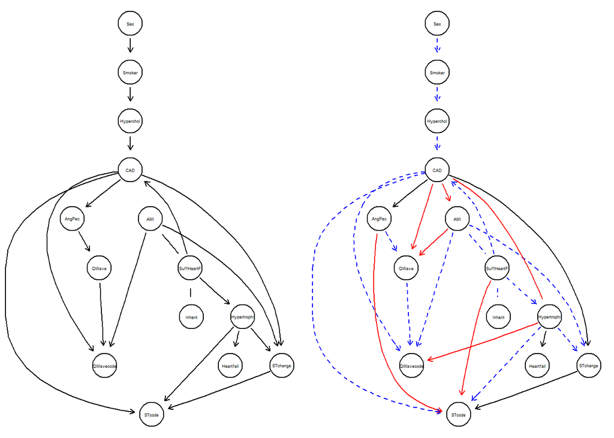

## Hybrid algorithms

```r
bn_rsmax <- rsmax2(cad1, restrict="mmpc", maximize="hc", blacklist = blackL)
```

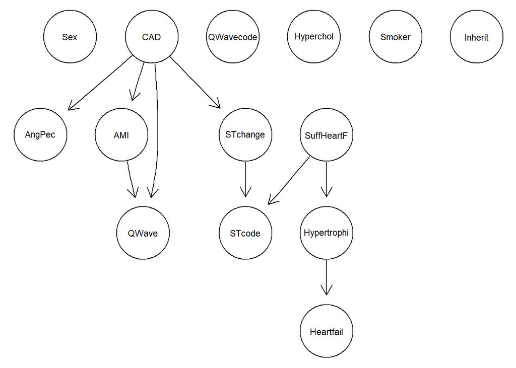

```r
unlist( bnlearn::compare(true_dag, cpdag( bn_rsmax)) )
```

```
## tp fp fn
##  1  8 18
```

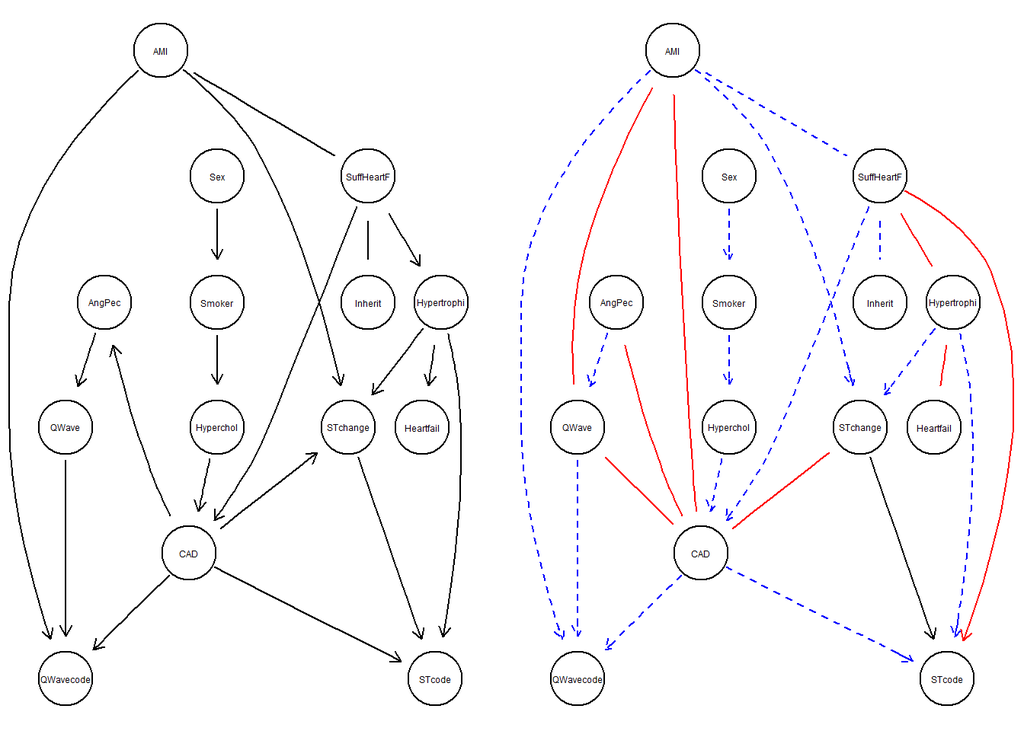

## Model averaging

### Frequentist approach

We average multiple networks to improve the structure learned. Bootstrap resampling is applied to the dataset to learn a set of 500 CPDAGS with the hill climbing algorithm. Arcs are considered significant if they appear in at least 85% of the networks, and in the direction that appears most frequently.

```r
boot <- boot.strength(cad1, R = 500, algorithm = "hc",
                      algorithm.args = list(score = "bde", iss = 10))

boot[(boot$strength > 0.85) & (boot$direction >= 0.5), ]
```

```
##            from         to strength direction
## 18       AngPec     STcode    0.902 0.7372506
## 26       AngPec        CAD    1.000 0.8610000
## 29          AMI      QWave    0.950 0.6463158
## 57    QWavecode     STcode    0.990 0.7151515
## 71       STcode   STchange    1.000 0.8910000
## 72       STcode SuffHeartF    1.000 0.8860000
## 111 Hypertrophi   STchange    0.878 0.8132118
## 116 Hypertrophi  Heartfail    1.000 0.7750000
## 172         CAD        AMI    0.990 0.5636364
## 173         CAD      QWave    0.976 0.6690574
## 176         CAD   STchange    0.964 0.6182573
## 179         CAD  Hyperchol    0.948 0.9704641
```

```r
avg.boot <- averaged.network(boot, threshold = 0.85)
```

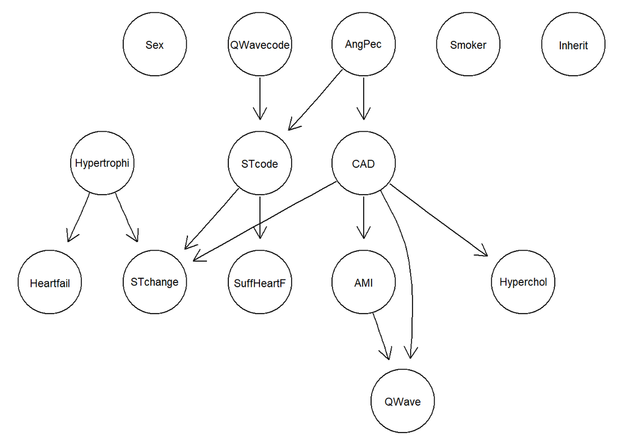

```r
unlist( bnlearn::compare(true_dag, cpdag( avg.boot)) )
```

```
## tp fp fn
##  2 10 17
```

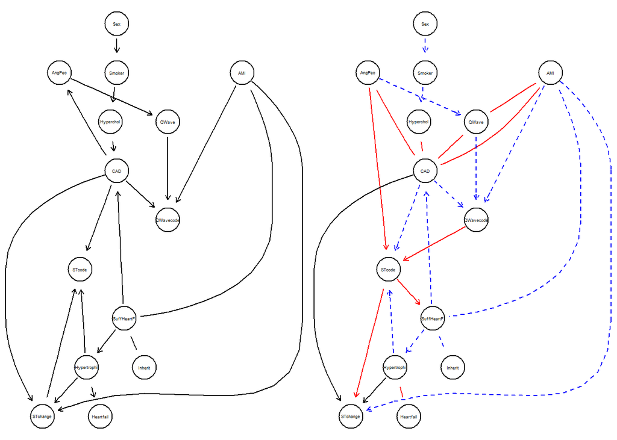

# Model comparison

Compare CPDAGS

|  | tp | fp | fn |
| --- | --- | --- | --- |
| HC restarts | 5 | 14 | 14 |
| HC | 7 | 11 | 12 |
| Hiton | 4 | 6 | 15 |
| Hiton permutations | 4 | 7 | 15 |
| Hybrid | 1 | 8 | 18 |
| Averaging | 2 | 10 | 17 |

Compare skeletons

|  | tp | fp | fn |
| --- | --- | --- | --- |
| HC restarts | 8 | 11 | 11 |
| HC | 8 | 10 | 11 |
| Hiton | 4 | 6 | 15 |
| Hiton permutations | 4 | 7 | 15 |
| Hybrid | 5 | 4 | 14 |
| Averaging | 6 | 6 | 13 |

The skeleton of the network learned by the HC algorithm differs from the skeleton of the true DAG by 21 arcs, while its CPDAG differs from the true CPDAG by 23 arcs.

Hamming distance

|  | Hamming distance | SHD |
| --- | --- | --- |
| HC restarts | 22 | 26 |
| HC | 21 | 23 |
| Hiton | 21 | 24 |
| Hiton permutations | 22 | 24 |
| Hybrid | 18 | 20 |
| Averaging | 19 | 22 |

# Parameter estimate

We choose to use the Bayesian network produced by the hill climbing algorithm for the purpose of statistical inference. The graph is chosen because it has the largest number of true positive arcs with respect to the true CPDAG among the estimated graphs. The networks produced by the constraint based algorithms and by the hybrid algorithms are not considered eligible for selection because the node CAD has no parents, making it impossible to inquire about the underlying causes of the disease.

The joint probability distribution of the model obtained with the hill climbing algorithm factorizes according to:

P(Sex, AngPec, AMI, QWave, QWavecode,STcode, STchange, SuffHeartF, Hypertrophi, Hyperchol, Smoker, Inherit,  
Heartfail, CAD ) = P(Sex)P(Inherit)P(SuffHeartF)P(Smoker|Sex)P(AMI|CAD)P(CAD| Inherit, Hyperchol) P(Hyperchol|Inherit, SuffHeartF) P(QWave|AMI, CAD) P(STchange| CAD, Hypertrophi) P(AngPec|CAD) P(Hypertrophi| CAD, SuffHeartF) P(Heartfail|Hypertrophi) P(QWavecode|Hypertrophi, SuffHeartF) P(STcode|STchange, SuffHeartF)

The MLE and the Bayes estimator yield similar results for the model coefficients.

```r
fit_mle = bn.fit(bn_hc, cad1, method ="mle")

coef(fit_mle$CAD)
```

```
## , , Inherit = No
##
##      Hyperchol
## CAD          No       Yes
##   No  0.8214286 0.4487179
##   Yes 0.1785714 0.5512821
##
## , , Inherit = Yes
##
##      Hyperchol
## CAD          No       Yes
##   No  0.5000000 0.2600000
##   Yes 0.5000000 0.7400000
```

```r
fit_bay = bn.fit(bn_hc, cad1, method = "bayes", iss = 10)

coef(fit_bay$CAD)
```

```
## , , Inherit = No
##
##      Hyperchol
## CAD          No       Yes
##   No  0.8121387 0.4503106
##   Yes 0.1878613 0.5496894
##
## , , Inherit = Yes
##
##      Hyperchol
## CAD          No       Yes
##   No  0.5000000 0.2714286
##   Yes 0.5000000 0.7285714
```

# Inference

## Exact inference

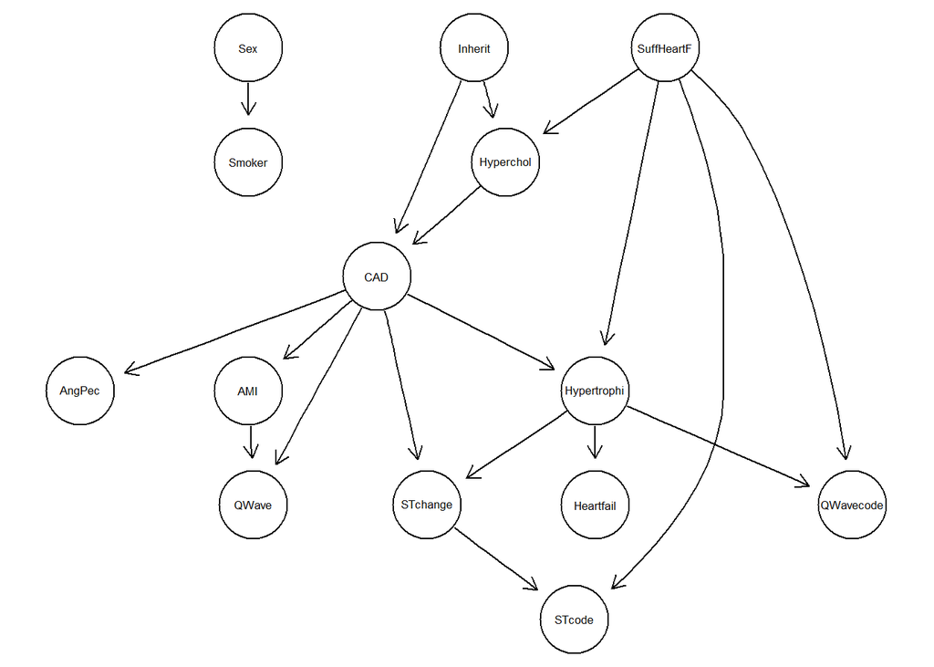

Bayesian network

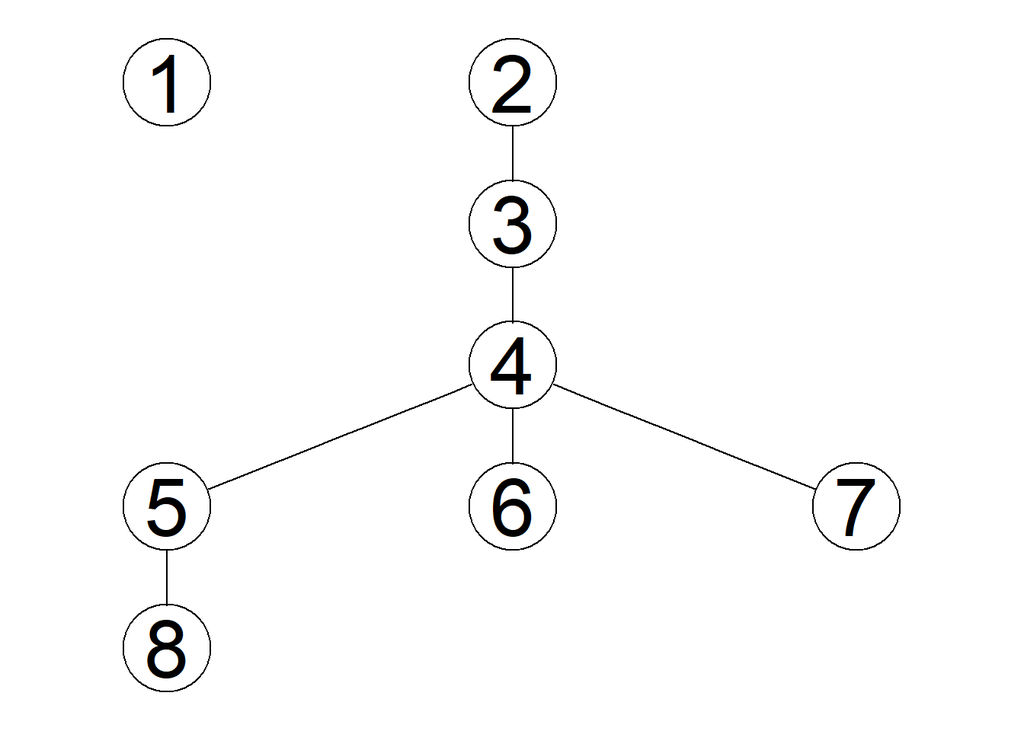

Junction tree

```r
querygrain(junction, nodes = "CAD")
```

```
## $CAD
## CAD
##        No       Yes
## 0.5464106 0.4535894
```

Since smoker is not directly connected to CAD in the graph, we find that $P(CAD| Smoker = Yes) = P(CAD)$.

```r
gr1.ev1 <- setFinding(junction,nodes=c("Smoker"),states=list(c("Yes")))
querygrain(gr1.ev1,nodes=c("CAD"),type = "marginal")
```

```
## $CAD
## CAD
##        No       Yes
## 0.5464106 0.4535894
```

In fact, the two nodes are d-separated in the original graph.

```r
bnlearn::dsep(bn_hc, x = "CAD", y = "Smoker")
```

```
## [1] TRUE
```

The probability of observing $CAD = Yes$ is higher for the evidence $Inherit = Yes$ (about 66%) since the two nodes are connected by an arc.

```r
gr1.ev1 <- setFinding(junction,nodes=c("Inherit"),states=list(c("Yes")))
querygrain(gr1.ev1,nodes=c("CAD"),type = "marginal")
```

```
## $CAD
## CAD
##        No       Yes
## 0.3377717 0.6622283
```

If both Inherit and Hypercol are present, the probability of CAD is about 74%

```r
gr1.ev2 <- setFinding(junction, nodes=c("Inherit", "Hyperchol"),states=list(c("Yes"), c( "Yes" )))
querygrain(gr1.ev2,nodes=c("CAD"),type = "marginal")
```

```
## $CAD
## CAD
##   No  Yes
## 0.26 0.74
```

Adding SuffHeart to the evidence does not change the probability distribution of CAD

```r
gr1.ev3 <- setFinding(junction, nodes=c("Inherit", "Hyperchol", "SuffHeartF"),states=list(c("Yes"), c( "Yes" ), c( "Yes" )))
querygrain(gr1.ev3,nodes=c("CAD"),type = "marginal")
```

```
## $CAD
## CAD
##   No  Yes
## 0.26 0.74
```

```r
gr1.ev4 <- setFinding(junction, nodes=c( "SuffHeartF"),states=list(c("Yes")))
querygrain(gr1.ev4,nodes=c("CAD"),type = "marginal")
```

```
## $CAD
## CAD
##        No       Yes
## 0.4931176 0.5068824
```

However, the two nodes are not d-separated in the orignal graph, since there is a path going from SuffHeartF to CAD.

```r
bnlearn::dsep(bn_hc, x = "SuffHeartF", y = "CAD")
```

```
## [1] FALSE
```

```r
bnlearn::path(bn_hc, from = "SuffHeartF", to = "CAD")
```

```
## [1] TRUE
```

SuffHeartF and CAD are not conditionally independent even if we condition on Hyperchol, since there exist other paths between the nodes.

```r
bnlearn::dsep(bn_hc, x = "SuffHeartF", y = "CAD", z = "Hyperchol")
```

```
## [1] FALSE
```

The presence of CAD makes AngPec and QWave more likely and Hypertrophi less likely

```r
gr1.ev5 <- setFinding(junction, nodes=c( "CAD"),states=list(c("Yes")))
querygrain(gr1.ev5,nodes=c("AngPec", "Hypertrophi", "QWave"),type = "marginal")
```

```
## $QWave
## QWave
##        No       Yes
## 0.4205607 0.5794393
##
## $AngPec
## AngPec
##   Atypical       None    Typical
## 0.05607477 0.12149533 0.82242991
##
## $Hypertrophi
## Hypertrophi
##        No       Yes
## 0.8589799 0.1410201
```

Next, we investigate the joint distribution of CAD and Hyperchol given that the patient has an hereditary predisposition.

```r
gr1.ev6 <- setFinding(junction, nodes=c(  "Inherit"), states=list(c("Yes")))
querygrain(gr1.ev6, nodes=c("CAD", "Hyperchol"), type = "joint")
```

```
##      Hyperchol
## CAD          No       Yes
##   No  0.1620244 0.1757473
##   Yes 0.1620244 0.5002039
```

Finally, we compute the probability of CAD conditional on the evidence and the values of Hyperchol $P(CAD| Inherit = Yes, Hypercol = h), h \in \{ Yes, No \}$.

```r
querygrain(gr1.ev6, nodes = c("CAD", "Hyperchol"), type = "conditional")
```

```
##      Hyperchol
## CAD    No  Yes
##   No  0.5 0.26
##   Yes 0.5 0.74
```

## Approximate inference

### Logic sampling

By generating $10^6$ observations from the fitted Bayesian network we find that $P(CAD = Yes | Inherit = Yes) = 0.65$ and $P(CAD = Yes | Hyperchol = Yes, Inherit = Yes) = 0.73$, in line with the previous findings obtained via exact inference. In both queries, $P(E)$ is large enough for the logic sampling algorithm to estimate the probability with sufficient precision, which is confirmed by the fact that the likelihood weighting approach yields similar results.

```r
cpquery(fit_bay, event=(CAD=="Yes"),
evidence = (Inherit=="Yes"), method="ls", n=10^6)
```

```
## [1] 0.6519972
```

```r
cpquery(fit_bay, event=(CAD=="Yes"),
evidence = (Inherit=="Yes") & (Hyperchol == "Yes"), method="ls", n=10^6)
```

```
## [1] 0.7289072
```

```r
cpquery(fit_bay, event=(CAD=="Yes"),
evidence = list(Inherit ="Yes", Hyperchol = "Yes"), method="lw")
```

```
## [1] 0.7225885
```

# Classification

## Naive Bayes Classifier

The naive Bayes classifier predicts the correct class about 85% of the time, whereas the original Bayesian network predicts the correct class only 67% of the time. Generating a random sample, as we did in this example, is optional since the database is large enough for the classifier to yield robust estimates even if applied to the original data.

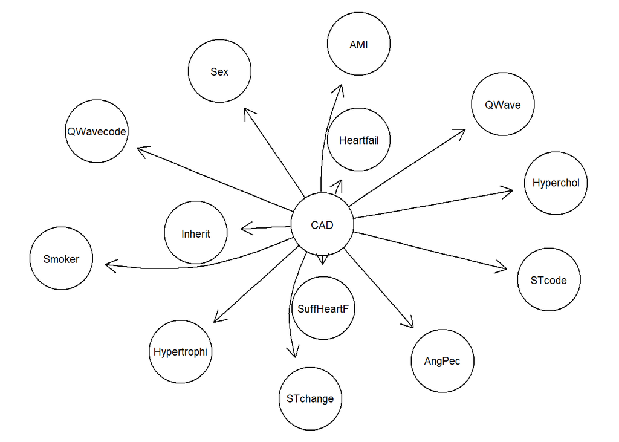

```r
set.seed(123)

survey <- bnlearn::rbn(fit_bay,1000)
nbcl <- naive.bayes (survey, training="CAD")
graphviz.plot(nbcl,layout="fdp")
```

```r
nbcl.trained <- bn.fit(nbcl,survey)

coef(nbcl.trained$CAD)
```

```
##    No   Yes
## 0.548 0.452
```

```r
coef(nbcl.trained$Hypertrophi)
```

```
##            CAD
## Hypertrophi        No       Yes
##         No  0.6478102 0.8539823
##         Yes 0.3521898 0.1460177
```

```r
set.seed(123)

cv.nb <- bn.cv(nbcl,data=survey,runs=10,
method="k-fold",folds=10)
cv.nb
```

```
##
##   k-fold cross-validation for Bayesian networks
##
##   target network structure:
##    [Naive Bayes Classifier]
##   number of folds:                       10
##   loss function:                         Classification Error (Posterior, exact)
##   training node:                         CAD
##   number of runs:                        10
##   average loss over the runs:            0.1465
##   standard deviation of the loss:        0.001900292
```

```r
set.seed(123)

cv.orig <- bn.cv(bn_hc, data = survey, runs=10, method ="k-fold", folds=10,
                 loss="pred", loss.args = list(target="CAD"))
cv.orig
```

```
##
##   k-fold cross-validation for Bayesian networks
##
##   target network structure:
##    [Sex][SuffHeartF][Inherit][Hyperchol|SuffHeartF:Inherit][Smoker|Sex]
##    [CAD|Hyperchol:Inherit][AngPec|CAD][AMI|CAD][Hypertrophi|SuffHeartF:CAD]
##    [QWave|AMI:CAD][QWavecode|SuffHeartF:Hypertrophi][STchange|Hypertrophi:CAD]
##    [Heartfail|Hypertrophi][STcode|STchange:SuffHeartF]
##   number of folds:                       10
##   loss function:                         Classification Error
##   training node:                         CAD
##   number of runs:                        10
##   average loss over the runs:            0.334
##   standard deviation of the loss:        0.004242641
```

## Tree-Augumented Naive Bayes Classifier

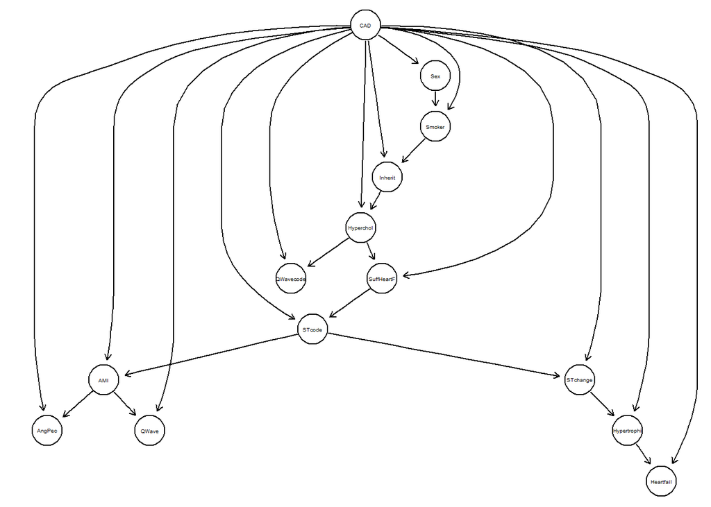

```r
set.seed(123)

tan.cl <- tree.bayes(survey,training="CAD")
graphviz.plot(tan.cl)
```

```r
tancl.trained <- bn.fit(tan.cl,survey)
coef(tancl.trained$CAD)
```

```
##    No   Yes
## 0.548 0.452
```

```r
tancl.trained <- bn.fit(tan.cl,survey)
coef(tancl.trained$Hypertrophi)
```

```
## , , STchange = No
##
##            CAD
## Hypertrophi         No        Yes
##         No  0.76354680 0.68604651
##         Yes 0.23645320 0.31395349
##
## , , STchange = Yes
##
##            CAD
## Hypertrophi         No        Yes
##         No  0.31690141 0.95714286
##         Yes 0.68309859 0.04285714
```

```r
set.seed(123)

cv.tan <- bn.cv("tree.bayes",data=survey,
                runs=10,
                method="k-fold",folds=10,algorithm.args = list(training ="CAD"))
cv.tan
```

```
##
##   k-fold cross-validation for Bayesian networks
##
##   target learning algorithm:             TAN Bayes Classifier
##   number of folds:                       10
##   loss function:                         Classification Error (Posterior, exact)
##   training node:                         CAD
##   number of runs:                        10
##   average loss over the runs:            0.1213
##   standard deviation of the loss:        0.003093003
```

By generating 1000 samples from the bayesian network we obtain a distribution with very low variance.

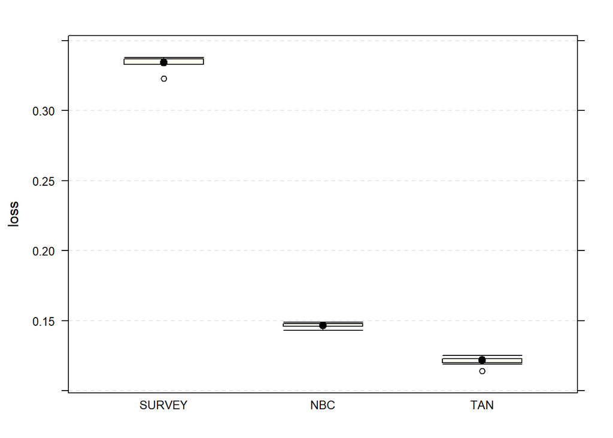

```r
plot(cv.orig,cv.nb,cv.tan, xlab=c("SURVEY","NBC","TAN"))
```